# DACSS 697D Post 7

text as data

homework

NYT text analysis project

Assignment 7 for DACSS 697D Course ‘Text as Data’: “Analyzing Print v. Web Headlines using Dictionary Methods”

Kristina Becvar https://www.kristinabecvar.com  
2022-04-09

## New Research Path: Comparing Different Headlines

After taking an initial look at the differences, I have cleaned the data further, and now want to look more closely at the differences in the fields for the “main headline” and “print headline” pulled from the API for similarity.

## Making Choices on Inclusion of Observations

In my initial look at the data, it was clear that not all of the articles had different headlines; some are the same entries, and some have “N/A” in the “print” version only, indicating they were online-only stories. Although I initially felt inclined to leave the “N/A” observations in the analysis, I removed those observations as they would not be relevant to my new research questions comparing the framing for different audiences.

I also removed whole sections where the API returned an observation as there was apparently use of the word “Afghanistan” somewhere in the article/entry, but the type of entry was clearly not being represented in the headline. For example, “Obituary” entries had headlines consisting primarily of just the name of the deceased and no further information. Similarly, “Corrections” entries have headlines consisting only of the term “Corrections” and the corresponding date. Similar choices were made on the “Books”, “Movies”, “Theater”, and “Food” sections when entries are primarily the names of the things being reviewed that may have a reference to Afghanistan somewhere in the text, but it is not relevant specifically to the withdrawal time period being analyzed.

At this point, I included the entirety of the “U.S.” and “World” news sections, even if the content related to Afghanistan is not readily observable.

I’ll start by loading the smaller headline data in more detail.

```
  doc.id
1      1
2      2
3      3
4      4
5      5
6      6
                                                                         headline.main
1                           Can Trump Make Foreign Policy a Democratic Campaign Issue?
2                                                         Serving in a Twenty-Year War
3                              Suleimani’s Gone, and the Iran Nuclear Deal May Be Next
4 In Era of Perpetual Conflict, a Volatile President Grabs Expanded Powers to Make War
5                        Muslims Organize Huge Protests Across India, Challenging Modi
6                                                     A War Without Winners Winds Down
       date section.name
1  1/8/2020      Opinion
2  9/8/2021         U.S.
3  1/3/2020        World
4  1/4/2020        World
5  1/4/2020        World
6 2/29/2020      Opinion
```

```
  doc.id                                          headline.print
1      1                  Foreign Policy Should Matter to Voters
2      2                                    Mission ‘Unfinished’
3      3 U.S. Strike May Have Dealt a Fatal Blow to Nuclear Deal
4      4        More Powers, Few Limits And a Volatile President
5      5  Huge Protests in India Keep Steadfast Pressure on Modi
6      6                        A War Without Winners Winds Down
       date section.name
1  1/8/2020      Opinion
2  9/8/2021         U.S.
3  1/3/2020        World
4  1/4/2020        World
5  1/4/2020        World
6 2/29/2020      Opinion
```

I want to create a corpus of each of the headline data frames for next step analysis:

```
  Text Types Tokens Sentences      date section.name
1    1    10     10         1  1/8/2020      Opinion
2    2     5      5         1  9/8/2021         U.S.
3    3    11     11         1  1/3/2020        World
4    4    15     15         1  1/4/2020        World
5    5     9      9         1  1/4/2020        World
6    6     6      6         1 2/29/2020      Opinion
```

```
  Text Types Tokens Sentences      date section.name
1    1     6      6         1  1/8/2020      Opinion
2    2     3      4         1  9/8/2021         U.S.
3    3    12     12         2  1/3/2020        World
4    4     9      9         1  1/4/2020        World
5    5     9      9         1  1/4/2020        World
6    6     6      6         1 2/29/2020      Opinion
```

## Tokenization

I finally realized how to remove the “�” symbol that has plagued me since starting working with this API by using “remove_symbols=TRUE” in addition to removing the punctuation when tokenizing:

```
Tokens consisting of 1,371 documents and 2 docvars.
1 :
[1] "Can"        "Trump"      "Make"       "Foreign"    "Policy"
[6] "a"          "Democratic" "Campaign"   "Issue"

2 :
[1] "Serving"     "in"          "a"           "Twenty-Year"
[5] "War"

3 :
 [1] "Suleimani's" "Gone"        "and"         "the"
 [5] "Iran"        "Nuclear"     "Deal"        "May"
 [9] "Be"          "Next"

4 :
 [1] "In"        "Era"       "of"        "Perpetual" "Conflict"
 [6] "a"         "Volatile"  "President" "Grabs"     "Expanded"
[11] "Powers"    "to"
[ ... and 2 more ]

5 :
[1] "Muslims"     "Organize"    "Huge"        "Protests"
[5] "Across"      "India"       "Challenging" "Modi"

6 :
[1] "A"       "War"     "Without" "Winners" "Winds"   "Down"

[ reached max_ndoc ... 1,365 more documents ]
```

```
Tokens consisting of 1,371 documents and 2 docvars.
1 :
[1] "Foreign" "Policy"  "Should"  "Matter"  "to"      "Voters"

2 :
[1] "Mission"    "Unfinished"

3 :
 [1] "U.S"     "Strike"  "May"     "Have"    "Dealt"   "a"
 [7] "Fatal"   "Blow"    "to"      "Nuclear" "Deal"

4 :
[1] "More"      "Powers"    "Few"       "Limits"    "And"
[6] "a"         "Volatile"  "President"

5 :
[1] "Huge"      "Protests"  "in"        "India"     "Keep"
[6] "Steadfast" "Pressure"  "on"        "Modi"

6 :
[1] "A"       "War"     "Without" "Winners" "Winds"   "Down"

[ reached max_ndoc ... 1,365 more documents ]
```

Now that I have been able to remove the symbols, I should be able to get a better dfm result. In addition to removing the punctuation, symbols, and stopwords, I also want to remove my new top result, “s”, because the tokenization removing contractions left many stranded “s” characters.

First, for the main headlines:

```
[1] 1371
```

```
Tokens consisting of 1,371 documents and 2 docvars.
1 :
[1] "Can"        "Trump"      "Make"       "Foreign"    "Policy"
[6] "Democratic" "Campaign"   "Issue"

2 :
[1] "Serving"     "Twenty-Year" "War"

3 :
[1] "Suleimani's" "Gone"        "Iran"        "Nuclear"
[5] "Deal"        "May"         "Next"

4 :
 [1] "Era"       "Perpetual" "Conflict"  "Volatile"  "President"
 [6] "Grabs"     "Expanded"  "Powers"    "Make"      "War"

5 :
[1] "Muslims"     "Organize"    "Huge"        "Protests"
[5] "Across"      "India"       "Challenging" "Modi"

6 :
[1] "War"     "Without" "Winners" "Winds"

[ reached max_ndoc ... 1,365 more documents ]
```

Then the print headlines:

```r
print_tokens <- tokens(print_corpus, remove_punct = TRUE) %>%
  tokens(print_corpus, remove_symbols = TRUE) %>%
  tokens_remove(stopwords("english")) %>%
  tokens_remove(c("s"))


main_dfm <- dfm(print_tokens)

length(print_tokens)
```

```
[1] 1371
```

```r
print(print_tokens)
```

```
Tokens consisting of 1,371 documents and 2 docvars.
1 :
[1] "Foreign" "Policy"  "Matter"  "Voters"

2 :
[1] "Mission"    "Unfinished"

3 :
[1] "U.S"     "Strike"  "May"     "Dealt"   "Fatal"   "Blow"
[7] "Nuclear" "Deal"

4 :
[1] "Powers"    "Limits"    "Volatile"  "President"

5 :
[1] "Huge"      "Protests"  "India"     "Keep"      "Steadfast"
[6] "Pressure"  "Modi"

6 :
[1] "War"     "Without" "Winners" "Winds"

[ reached max_ndoc ... 1,365 more documents ]
```

Now I can use quanteda to generate the document-feature matrices

```r
main_dfm <- dfm(main_tokens)
main_dfm
```

```
Document-feature matrix of: 1,371 documents, 3,432 features (99.79% sparse) and 2 docvars.
    features
docs can trump make foreign policy democratic campaign issue serving
   1   1     1    1       1      1          1        1     1       0
   2   0     0    0       0      0          0        0     0       1
   3   0     0    0       0      0          0        0     0       0
   4   0     0    1       0      0          0        0     0       0
   5   0     0    0       0      0          0        0     0       0
   6   0     0    0       0      0          0        0     0       0
    features
docs twenty-year
   1           0
   2           1
   3           0
   4           0
   5           0
   6           0
[ reached max_ndoc ... 1,365 more documents, reached max_nfeat ... 3,422 more features ]
```

```r
print_dfm <- dfm(print_tokens)
print_dfm
```

```
Document-feature matrix of: 1,371 documents, 3,327 features (99.81% sparse) and 2 docvars.
    features
docs foreign policy matter voters mission unfinished u.s strike may
   1       1      1      1      1       0          0   0      0   0
   2       0      0      0      0       1          1   0      0   0
   3       0      0      0      0       0          0   1      1   1
   4       0      0      0      0       0          0   0      0   0
   5       0      0      0      0       0          0   0      0   0
   6       0      0      0      0       0          0   0      0   0
    features
docs dealt
   1     0
   2     0
   3     1
   4     0
   5     0
   6     0
[ reached max_ndoc ... 1,365 more documents, reached max_nfeat ... 3,317 more features ]
```

```r
#create a word frequency variable and the rankings
main_counts <- as.data.frame(sort(colSums(main_dfm),dec=T))
colnames(main_counts) <- c("Frequency")
main_counts$Rank <- c(1:ncol(main_dfm))
head(main_counts)
```

```
            Frequency Rank
u.s               240    1
afghanistan       202    2
afghan            200    3
taliban           150    4
biden             120    5
war                96    6
```

```r
print_counts <- as.data.frame(sort(colSums(print_dfm),dec=T))
colnames(print_counts) <- c("Frequency")
print_counts$Rank <- c(1:ncol(print_dfm))
head(print_counts)
```

```
            Frequency Rank
u.s               236    1
afghan            148    2
taliban           145    3
afghanistan       134    4
biden              93    5
war                83    6
```

Now I can take a look at this network of feature co-occurrences for the main headlines:

```
[1] 3432 3432
```

```
[1] 20 20
```

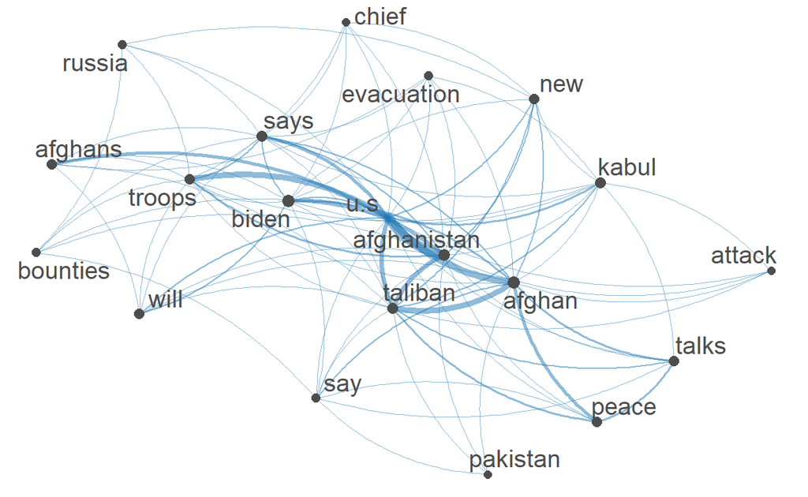

and for the print headlines:

```
[1] 3327 3327
```

```
[1] 20 20
```

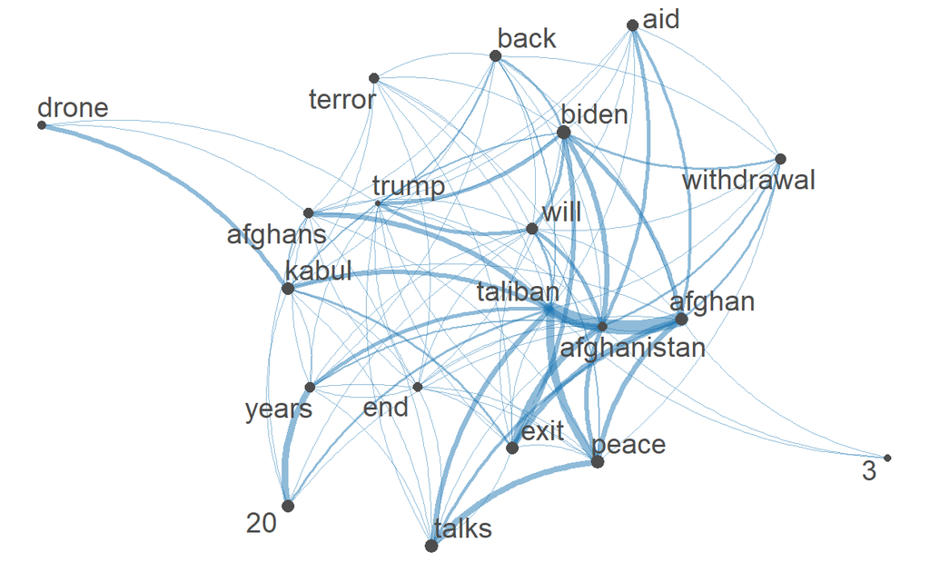

This brings me to where I had previously stopped in my comparison and analysis, and now that I’m able to produce a cleaner result, I’ll move on to further analysis using the quanteda dictionary.

## Dictionary Analysis

```r
# convert tokens from each headline data set to DFM using the dictionary "NRC"
main_nrc <- dfm(main_tokens) %>%
  dfm_lookup(data_dictionary_NRC)
print_nrc <- dfm(print_tokens) %>%
  dfm_lookup(data_dictionary_NRC)

dim(main_nrc)
```

```
[1] 1371   10
```

```r
main_nrc
```

```
Document-feature matrix of: 1,371 documents, 10 features (68.56% sparse) and 2 docvars.
    features
docs anger anticipation disgust fear joy negative positive sadness
   1     0            0       0    0   0        1        0       0
   2     0            0       0    1   0        1        0       0
   3     0            1       0    0   1        0        1       0
   4     1            0       0    2   0        2        1       1
   5     0            0       0    0   0        0        1       0
   6     0            0       0    1   0        1        0       0
    features
docs surprise trust
   1        1     1
   2        0     0
   3        1     1
   4        0     1
   5        0     0
   6        0     0
[ reached max_ndoc ... 1,365 more documents ]
```

```r
dim(print_nrc)
```

```
[1] 1371   10
```

```r
print_nrc
```

```
Document-feature matrix of: 1,371 documents, 10 features (69.85% sparse) and 2 docvars.
    features
docs anger anticipation disgust fear joy negative positive sadness
   1     0            0       0    0   0        1        0       0
   2     0            0       0    0   0        1        0       0
   3     2            1       0    1   1        2        1       1
   4     0            0       0    0   0        0        1       0
   5     0            0       0    0   0        1        1       0
   6     0            0       0    1   0        1        0       0
    features
docs surprise trust
   1        0     1
   2        0     0
   3        1     1
   4        0     1
   5        0     1
   6        0     0
[ reached max_ndoc ... 1,365 more documents ]
```

And use the information in a data frame to plot the output:

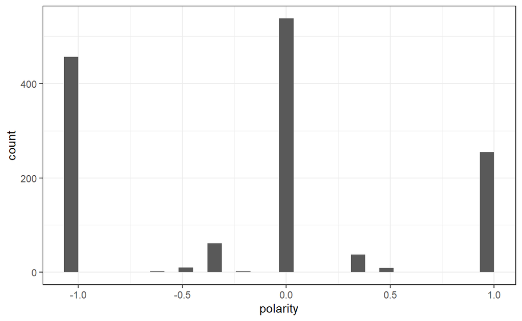

```r
#for the main headlines
df_main_nrc <- convert(main_nrc, to = "data.frame")
df_main_nrc$polarity <- (df_main_nrc$positive - df_main_nrc$negative)/(df_main_nrc$positive + df_main_nrc$negative)
df_main_nrc$polarity[which((df_main_nrc$positive + df_main_nrc$negative) == 0)] <- 0

ggplot(df_main_nrc) +
  geom_histogram(aes(x=polarity)) +
  theme_bw()
```

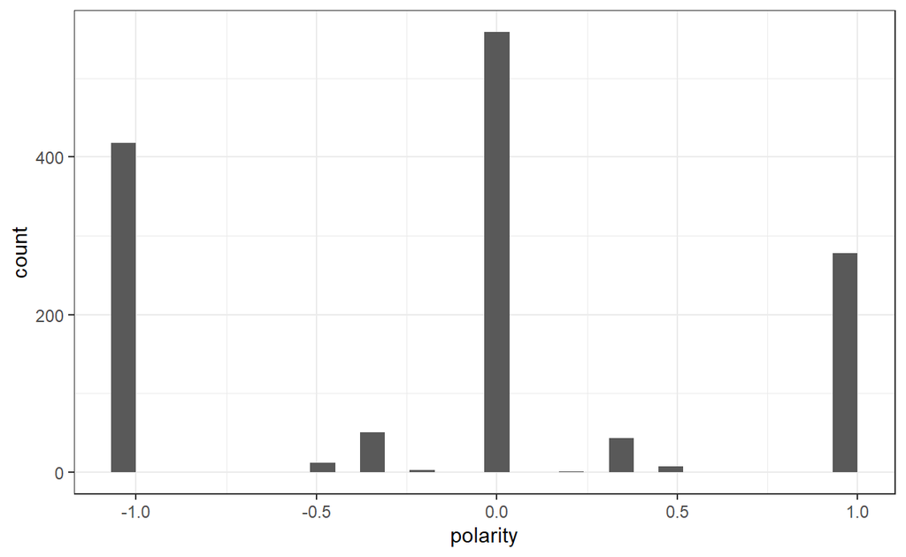

```r
#and the print headlines
df_print_nrc <- convert(print_nrc, to = "data.frame")
df_print_nrc$polarity <- (df_print_nrc$positive - df_print_nrc$negative)/(df_print_nrc$positive + df_print_nrc$negative)
df_print_nrc$polarity[which((df_print_nrc$positive + df_print_nrc$negative) == 0)] <- 0

ggplot(df_print_nrc) +
  geom_histogram(aes(x=polarity)) +
  theme_bw()
```

Looking at the headlines that are indicated as “1”, or positive in sentiment, it’s clear that this dictionary is not capturing the sentiment accurately.

```r
head(main_corpus[which(df_main_nrc$polarity == 1)])
```

```
Corpus consisting of 6 documents and 2 docvars.
3 :
"Suleimani’s Gone, and the Iran Nuclear Deal May Be Next"

5 :
"Muslims Organize Huge Protests Across India, Challenging Mod..."

14 :
"Trump Isn’t Telling Us Everything About His Deal With the Ta..."

28 :
"Mohammed bin Zayed’s Dark Vision of the Middle East’s Future"

29 :
"He Fled Iran as a Child. Now He’s Commanding a U.S. Aircraft..."

30 :
"Pentagon Rules Out Striking Iranian Cultural Sites, Contradi..."
```

```r
head(print_corpus[which(df_print_nrc$polarity == 1)])
```

```
Corpus consisting of 6 documents and 2 docvars.
4 :
"More Powers, Few Limits And a Volatile President"

7 :
"As Tehran and Washington Stare Each Other Down, ISIS Stands ..."

9 :
"References In Address To 2013 Deal Had Holes"

10 :
"President Exaggerates His Own Record On Funding Pentagon and..."

20 :
"Majority Leader Says a Briefing for the Senate Is Scheduled ..."

22 :
"Victims Included Citizens From at Least 7 Countries"
```

I am going to want to look at multiple dictionaries to see if one can best apply to this data. First, the LSD 2015 dictionary:

```r
# convert main corpus to DFM using the LSD2015 dictionary
main_lsd2015 <- dfm(tokens(main_corpus, remove_punct = TRUE),
                              tolower = TRUE) %>%
                          dfm_lookup(data_dictionary_LSD2015)
# create main polarity measure for LSD2015
main_lsd2015 <- convert(main_lsd2015, to = "data.frame")
main_lsd2015$polarity <- (main_lsd2015$positive - main_lsd2015$negative)/(main_lsd2015$positive + main_lsd2015$negative)
main_lsd2015$polarity[which((main_lsd2015$positive + main_lsd2015$negative) == 0)] <- 0
# convert print corpus to DFM using the LSD2015 dictionary
print_lsd2015 <- dfm(tokens(print_corpus, remove_punct = TRUE),
                              tolower = TRUE) %>%
                          dfm_lookup(data_dictionary_LSD2015)
# create print polarity measure for LSD2015
print_lsd2015 <- convert(print_lsd2015, to = "data.frame")
print_lsd2015$polarity <- (print_lsd2015$positive - print_lsd2015$negative)/(print_lsd2015$positive + print_lsd2015$negative)
print_lsd2015$polarity[which((print_lsd2015$positive + print_lsd2015$negative) == 0)] <- 0
```

and the General Inquirer dictionary:

```r
# convert main corpus to DFM using the General Inquirer dictionary
main_geninq <- dfm(tokens(main_corpus, remove_punct = TRUE),
                             tolower = TRUE) %>%
                    dfm_lookup(data_dictionary_geninqposneg)
# create main polarity measure for GenInq
main_geninq <- convert(main_geninq, to = "data.frame")
main_geninq$polarity <- (main_geninq$positive - main_geninq$negative)/(main_geninq$positive + main_geninq$negative)
main_geninq$polarity[which((main_geninq$positive + main_geninq$negative) == 0)] <- 0
# convert print corpus to DFM using the General Inquirer dictionary
print_geninq <- dfm(tokens(print_corpus, remove_punct = TRUE),
                             tolower = TRUE) %>%
                    dfm_lookup(data_dictionary_geninqposneg)
# create print polarity measure for GenInq
print_geninq <- convert(print_geninq, to = "data.frame")
print_geninq$polarity <- (print_geninq$positive - print_geninq$negative)/(print_geninq$positive + print_geninq $negative)
print_geninq$polarity[which((print_geninq$positive + print_geninq$negative) == 0)] <- 0
```

Now I’m going to be able to compare the different dictionary scores in one data frame for each type of headline.

```
  nrc_doc_id nrc_anger nrc_anticipation nrc_disgust nrc_fear nrc_joy
1          1         0                0           0        0       0
2         10         0                0           0        1       0
3        100         1                3           1        1       2
4       1000         0                0           0        0       0
5       1001         0                0           0        0       0
6       1002         0                1           0        0       1
  nrc_negative nrc_positive nrc_sadness nrc_surprise nrc_trust
1            1            0           0            1         1
2            1            1           0            1         0
3            1            2           0            1         1
4            1            0           1            0         0
5            0            2           0            0         1
6            1            1           0            0         2
  nrc_polarity lsd2015_negative lsd2015_positive lsd2015_neg_positive
```

[output cut: 20 more lines]

```
  nrc_doc_id nrc_anger nrc_anticipation nrc_disgust nrc_fear nrc_joy
1          1         0                0           0        0       0
2         10         0                0           0        0       0
3        100         1                1           0        0       2
4       1000         0                0           0        0       0
5       1001         1                0           0        1       0
6       1002         0                0           0        0       0
  nrc_negative nrc_positive nrc_sadness nrc_surprise nrc_trust
1            1            0           0            0         1
2            0            1           0            0         1
3            1            2           1            1         1
4            1            0           1            0         0
5            2            0           1            0         1
6            1            1           0            0         1
  nrc_polarity lsd2015_negative lsd2015_positive lsd2015_neg_positive
```

[output cut: 20 more lines]

Now that we have them all in a single data frame, it’s straightforward to figure out a bit about how well our different measures of polarity agree across the different approaches by looking at their correlation using the “cor()” function.

```r
cor(main_sent$nrc_polarity, main_sent$lsd2015_polarity)
```

```
[1] 0.4787681
```

```r
cor(main_sent$nrc_polarity, main_sent$geninq_polarity)
```

```
[1] 0.4746162
```

```r
cor(main_sent$lsd2015_polarity, main_sent$geninq_polarity)
```

```
[1] 0.5205449
```

```r
cor(print_sent$nrc_polarity, print_sent$lsd2015_polarity)
```

```
[1] 0.4984596
```

```r
cor(print_sent$nrc_polarity, print_sent$geninq_polarity)
```

```
[1] 0.5085233
```

```r
cor(print_sent$lsd2015_polarity, print_sent$geninq_polarity)
```

```
[1] 0.5235135
```